# STAT 140

FALL 2019

## Confidence Intervals

## CONFIDENCE INTERVAL

A plausible range of values for a population parameter is called a **confidence interval**.

Using only a sample statistic to estimate a population parameter is like fishing in a murky pond with a spear. Using a confidence interval is like fishing with a net.

- If we report a point estimate, we probably won’t hit the exact population parameter.
- If we report a range of plausible values (a **confidence interval**) we have a good shot at capturing the parameter.

## FACEBOOK’S CATEGORIZATION OF USER INTERESTS

Most commercial websites (e.g. social media platforms, news outlets, online retailers) collect a data about their users’ behaviors and use these data to deliver targeted content, recommendations, and ads. To understand whether Americans think their lives line up with how the algorithm-driven classification systems categorizes them, [Pew Research asked a representative sample of 850 American Facebook users how accurately they feel the list of categories Facebook has listed for them on the page of their supposed interests actually represents them and their interests](https://www.pewinternet.org/2019/01/16/facebook-algorithms-and-personal-data/). 67% of the respondents said that the listed categories were accurate. **Estimate the true proportion of American Facebook users who think the Facebook categorizes their interests accurately.**

## FACEBOOK’S CATEGORIZATION OF USER INTERESTS

\(\hat{p}=0.67\); \(n=850\)

The **approximate 95% confidence interval for a sample proportion** is defined as

\[\underbrace{\hat{p}}_{\text{point estimate}}\pm \underbrace{1.96\times SE}_{\text{margin of error}}\]

## FACEBOOK’S CATEGORIZATION OF USER INTERESTS

\(\hat{p}=0.67\); \(n=850\)

The **approximate 95% confidence interval for a sample proportion** is defined as

\[\underbrace{\hat{p}}_{\text{point estimate}}\pm \underbrace{1.96\times SE}_{\text{margin of error}}\]

\[SE=\sqrt{\frac{p(1-p)}{n}}\approx \sqrt{\frac{\hat{p}(1-\hat{p})}{n}}=\sqrt{\frac{0.67\times 0.33}{850}}=0.016\]

\[ \hat{p}\pm 1.96\times SE = 0.67 \pm 1.96\times 0.016 = (0.67-0.03,0.67+0.03)=(0.64,0.70) \]

## FACEBOOK’S CATEGORIZATION OF USER INTERESTS

Which of the following is the correct interpretation of this confidence interval? We are 95% confident that…

1. 64% to 70% of American Facebook users in this sample think Facebook categorizes their interests accurately.
2. 64% to 70% of all American Facebook users think Facebook categorizes their interests accurately.
3. there is a 64% to 70% chance that a randomly chosen American Facebook user’s interests are categorized accurately.
4. there is a 64% to 70% chance that 95% of American Facebook users’ interests are categorized accurately.

## FACEBOOK’S CATEGORIZATION OF USER INTERESTS

Which of the following is the correct interpretation of this confidence interval? We are 95% confident that…

1. 64% to 70% of American Facebook users in this sample think Facebook categorizes their interests accurately.
2. **64% to 70% of all American Facebook users think Facebook categorizes their interests accurately.**
3. there is a 64% to 70% chance that a randomly chosen American Facebook user’s interests are categorized accurately.
4. there is a 64% to 70% chance that 95% of American Facebook users’ interests are categorized accurately.

## WHAT DOES 95% CONFIDENT MEAN?

Suppose we took many samples and built a confidence interval from each sample using the equation

\[\hat{p} \pm 1.96 \times SE\]

Then about 95% of those intervals would contain the true population proportion (\(p\)).

## WIDTH OF AN INTERVAL

If we want to be more certain that we capture the population parameter, i.e. increase our confidence level, should we use a wider interval or a smaller interval?

## WIDTH OF AN INTERVAL

If we want to be more certain that we capture the population parameter, i.e. increase our confidence level, should we use a wider interval or a smaller interval?

A wider interval

## WIDTH OF AN INTERVAL

If we want to be more certain that we capture the population parameter, i.e. increase our confidence level, should we use a wider interval or a smaller interval?

A wider interval

Can you see any drawbacks to using a wider interval?

## WIDTH OF AN INTERVAL

If we want to be more certain that we capture the population parameter, i.e. increase our confidence level, should we use a wider interval or a smaller interval?

A wider interval

Can you see any drawbacks to using a wider interval?

[figure not shown]

## WIDTH OF AN INTERVAL

If we want to be more certain that we capture the population parameter, i.e. increase our confidence level, should we use a wider interval or a smaller interval?

A wider interval

Can you see any drawbacks to using a wider interval?

[figure not shown]

If the interval is too wide, it may not be very informative.

## CHANGING THE CONFIDENCE LEVEL

\[ \hat{p}\pm z^*\times SE\]

- In a confidence interval, \(z^*\times SE\) is called the margin of error, and for a given sample, the margin of error changes as the confidence level changes.
- In order to change the confidence level we need to adjust \(z^*\) in the above formula.
- Commonly used confidence levels in practice are 90%, 95%, 98%, and 99%. For a 95% confidence interval, \(z^*= 1.96\).
- However, using the standard normal (z) distribution, it is possible to find the appropriate \(z^*\) for any confidence level.

## PRACTICE

Which of the below Z scores is the appropriate \(z^*\) when calculating a 98% confidence interval?

1. Z = 2.05
2. Z = 1.96
3. Z = 2.33
4. Z = -2.33
5. Z = -1.65

## PRACTICE

Which of the below Z scores is the appropriate \(z^*\) when calculating a 98% confidence interval?

1. Z = 2.05
2. Z = 1.96
3. Z = 2.33
4. Z = -2.33
5. Z = -1.65

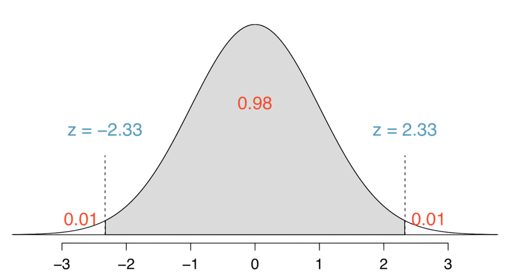

## INTERPRETING CONFIDENCE INTERVALS

Confidence intervals are:

- always about the population
- are not probability statements
- only about population parameters, not individual observations
- only reliable if the sample statistic they’re based on is an unbiased estimator of the population parameter

## Hypothesis Testing

## GENDER DISCRIMINATION

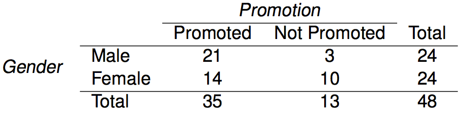

## GENDER DISCRIMINATION

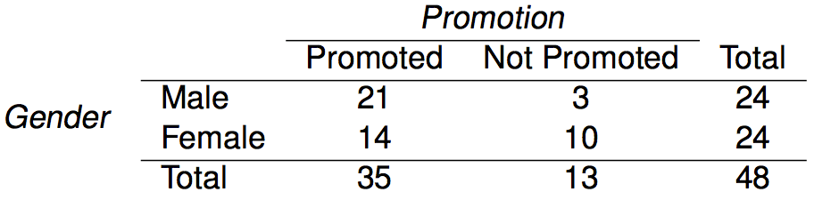

\[P(\text{promotion}|M): \ \hat{p}_{males}=21/24=0.88\]

\[P(\text{promotion}|F): \ \hat{p}_{females}=14/24=0.58\]

## GENDER DISCRIMINATION

\[P(\text{promotion}|M): \ \hat{p}_{males}=21/24=0.88\]

\[P(\text{promotion}|F): \ \hat{p}_{females}=14/24=0.58\]

**Possible explanations:**

- Promotion and gender are independent, no gender discrimination, observed difference in proportions is simply due to chance \(\rightarrow\) null (nothing is going on)
- Promotion and gender are dependent, there is gender discrimination, observed difference in proportions is not due to chance \(\rightarrow\) alternative (something is going on)

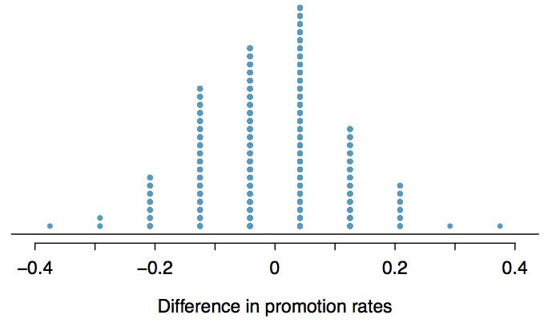

Since it was quite unlikely to obtain results like the actual data or something more extreme in the simulations (male promotions being 30% or more higher than female promotions), we decided to reject the null hypothesis in favor of the alternative.

## HYPOTHESIS TESTING FRAMEWORK

- We start with a **null hypothesis** (\(H_0\)) that represents the status quo.
- We also have an **alternative hypothesis** (\(H_A\)) that represents our research question, i.e. what we’re testing for.
- We conduct a hypothesis test under the assumption that the null hypothesis is true, either via simulation or traditional methods based on the central limit theorem.
- If the test results suggest that the data do not provide convincing evidence for the alternative hypothesis, we stick with the null hypothesis. - If they do, then we reject the null hypothesis in favor of the alternative.

## TESTING HYPOTHESES USING CONFIDENCE INTERVALS

Earlier we calculated a 95% confidence interval for the proporton of American Facebook users who think Facebook categorizes their interests accurately as 64% to 70%. Based on this confidence interval, do the data support the hypothesis that a majority of American Facebook users think Facebook categorizes their interests accurately?

## TESTING HYPOTHESES USING CONFIDENCE INTERVALS

The associated hypotheses are:

- \(H_0: p = 0.50\): 50% of American Facebook users think Facebook categorizes their interests accurately
- \(H_A: p > 0.50\): More than 50% of American Facebook users think Facebook categorizes their interests accurately

Null value is not included in the interval \(\rightarrow\) reject the null hypothesis.

This tells us to reject \(H_0\), but it doesn’t tell us the likelihood of certain outcomes under the null hypothesis ( p-value)

## FACEBOOK INTEREST CATEGORIES

The same survey asked the 850 respondents how comfortable they are with Facebook creating a list of categories for them. 41% of the respondents said they are comfortable. Do these data provide convincing evidence that the proportion of American Facebook users are comfortable with Facebook creating a list of interest categories for them is different than 50%?

## FACEBOOK INTEREST CATEGORIES

**Setting the hypotheses**

The parameter of interest is the proportion of all American Facebook users who are comfortable with Facebook creating categories of interests for them.

There may be two explanations why our sample proportion is lower than 0.50 (minority).

- The true population proportion is different than 0.50.
- The true population mean is 0.50, and the difference between the true population proportion and the sample proportion is simply due to natural sampling variability.

## FACEBOOK INTEREST CATEGORIES

**Setting the hypotheses**

The parameter of interest is the proportion of all American Facebook users who are comfortable with Facebook creating categories of interests for them.

There may be two explanations why our sample proportion is lower than 0.50 (minority).

## FACEBOOK INTEREST CATEGORIES - CONDITIONS

Which of the following is **not** a condition that needs to be met to proceed with this hypothesis test?

1. Respondents in the sample should be independent of each other with respect to whether or not they feel comfortable with their interests being categorized by Facebook.
2. Sampling should have been done randomly.
3. The sample size should be less than 10% of the population of all American Facebook users.
4. There should be at least 30 respondents in the sample.
5. The expected mean and variance should each be greater than 10.

## FACEBOOK INTEREST CATEGORIES - CONDITIONS

Which of the following is **not** a condition that needs to be met to proceed with this hypothesis test?

1. Respondents in the sample should be independent of each other with respect to whether or not they feel comfortable with their interests being categorized by Facebook.
2. Sampling should have been done randomly.
3. The sample size should be less than 10% of the population of all American Facebook users.
4. **There should be at least 30 respondents in the sample.**
5. The expected mean and variance should each be greater than 10.

## TEST STATISTIC

In order to evaluate if the observed sample mean is unusual for the hypothesized sampling distribution, we determine how many standard errors away from the null it is, which is also called the **test statistic**.

\[\hat{p} \sim Normal\left(\mu=0.5, SE=\sqrt{\frac{0.5\times 0.5}{850}}\right)\] \[Z=\frac{0.41-0.50}{0.0171}= -5.26\]

The sample proportion is 5.26 standard errors away from the hypothesized value. Is this considered unusually low? That is, is the result statistically significant?

## P-VALUE

We then use this test statistic to calculate the p-value, the probability of observing data at least as favorable to the alternative hypothesis as our current data set, if the null hypothesis were true.

If the p-value is low (lower than the significance level, \(\alpha\), which is usually 5%) we say that it would be very unlikely to observe the data if the null hypothesis were true, and hence reject \(H_0\).

If the p-value is high (higher than \(\alpha\)) we say that it is likely to observe the data even if the null hypothesis were true, and hence do not reject \(H_0\).

## SHOULD WE USE P-VALUES?

[ASA Statement on P-values](https://www.amstat.org/asa/files/pdfs/P-ValueStatement.pdf)

## REFERENCES

- Diez et al. (2019) OpenIntro Statistics, Fourth Edition